# Risk Factor Analysis

## Outcome Variable

**Outcome Variable:** pers_wast

## Predictor Variables

**Intervention Variable:** birthwt

**Adjustment Set:**

- arm
- sex
- W_mage
- meducyrs
- feducyrs
- hhwealth_quart
- vagbrth
- W_nrooms
- brthmon
- W_parity
- impsan
- delta_W_mage
- delta_meducyrs
- delta_feducyrs
- delta_hhwealth_quart
- delta_vagbrth
- delta_W_nrooms
- delta_brthmon
- delta_W_parity
- delta_impsan

## Stratifying Variables

The analysis was stratified on these variable(s):

- agecat
- studyid
- country

## Data Summary

| agecat | studyid | country | birthwt | pers_wast | n_cell | n |
| --- | --- | --- | --- | --- | --- | --- |
| 0-24 months | ki0047075b-MAL-ED | BANGLADESH | Normal or high birthweight | 0 | 185 | 242 |
| 0-24 months | ki0047075b-MAL-ED | BANGLADESH | Normal or high birthweight | 1 | 8 | 242 |
| 0-24 months | ki0047075b-MAL-ED | BANGLADESH | Low birth weight | 0 | 45 | 242 |
| 0-24 months | ki0047075b-MAL-ED | BANGLADESH | Low birth weight | 1 | 4 | 242 |
| 0-24 months | ki0047075b-MAL-ED | BRAZIL | Normal or high birthweight | 0 | 205 | 217 |
| 0-24 months | ki0047075b-MAL-ED | BRAZIL | Normal or high birthweight | 1 | 2 | 217 |
| 0-24 months | ki0047075b-MAL-ED | BRAZIL | Low birth weight | 0 | 10 | 217 |
| 0-24 months | ki0047075b-MAL-ED | BRAZIL | Low birth weight | 1 | 0 | 217 |
| 0-24 months | ki0047075b-MAL-ED | INDIA | Normal or high birthweight | 0 | 181 | 233 |
| 0-24 months | ki0047075b-MAL-ED | INDIA | Normal or high birthweight | 1 | 14 | 233 |
| 0-24 months | ki0047075b-MAL-ED | INDIA | Low birth weight | 0 | 33 | 233 |
| 0-24 months | ki0047075b-MAL-ED | INDIA | Low birth weight | 1 | 5 | 233 |
| 0-24 months | ki0047075b-MAL-ED | NEPAL | Normal or high birthweight | 0 | 207 | 231 |
| 0-24 months | ki0047075b-MAL-ED | NEPAL | Normal or high birthweight | 1 | 3 | 231 |
| 0-24 months | ki0047075b-MAL-ED | NEPAL | Low birth weight | 0 | 21 | 231 |
| 0-24 months | ki0047075b-MAL-ED | NEPAL | Low birth weight | 1 | 0 | 231 |
| 0-24 months | ki0047075b-MAL-ED | PERU | Normal or high birthweight | 0 | 262 | 281 |
| 0-24 months | ki0047075b-MAL-ED | PERU | Normal or high birthweight | 1 | 1 | 281 |
| 0-24 months | ki0047075b-MAL-ED | PERU | Low birth weight | 0 | 18 | 281 |
| 0-24 months | ki0047075b-MAL-ED | PERU | Low birth weight | 1 | 0 | 281 |
| 0-24 months | ki0047075b-MAL-ED | SOUTH AFRICA | Normal or high birthweight | 0 | 254 | 273 |
| 0-24 months | ki0047075b-MAL-ED | SOUTH AFRICA | Normal or high birthweight | 1 | 2 | 273 |
| 0-24 months | ki0047075b-MAL-ED | SOUTH AFRICA | Low birth weight | 0 | 17 | 273 |
| 0-24 months | ki0047075b-MAL-ED | SOUTH AFRICA | Low birth weight | 1 | 0 | 273 |
| 0-24 months | ki0047075b-MAL-ED | TANZANIA, UNITED REPUBLIC OF | Normal or high birthweight | 0 | 123 | 129 |
| 0-24 months | ki0047075b-MAL-ED | TANZANIA, UNITED REPUBLIC OF | Normal or high birthweight | 1 | 0 | 129 |
| 0-24 months | ki0047075b-MAL-ED | TANZANIA, UNITED REPUBLIC OF | Low birth weight | 0 | 6 | 129 |
| 0-24 months | ki0047075b-MAL-ED | TANZANIA, UNITED REPUBLIC OF | Low birth weight | 1 | 0 | 129 |
| 0-24 months | ki1000108-CMC-V-BCS-2002 | INDIA | Normal or high birthweight | 0 | 312 | 373 |
| 0-24 months | ki1000108-CMC-V-BCS-2002 | INDIA | Normal or high birthweight | 1 | 18 | 373 |

[output cut: 262 more lines]

The following strata were considered:

- agecat: 0-24 months, studyid: ki0047075b-MAL-ED, country: BANGLADESH
- agecat: 0-24 months, studyid: ki0047075b-MAL-ED, country: BRAZIL
- agecat: 0-24 months, studyid: ki0047075b-MAL-ED, country: INDIA
- agecat: 0-24 months, studyid: ki0047075b-MAL-ED, country: NEPAL
- agecat: 0-24 months, studyid: ki0047075b-MAL-ED, country: PERU
- agecat: 0-24 months, studyid: ki0047075b-MAL-ED, country: SOUTH AFRICA
- agecat: 0-24 months, studyid: ki0047075b-MAL-ED, country: TANZANIA, UNITED REPUBLIC OF
- agecat: 0-24 months, studyid: ki1000108-CMC-V-BCS-2002, country: INDIA
- agecat: 0-24 months, studyid: ki1000108-IRC, country: INDIA
- agecat: 0-24 months, studyid: ki1000109-EE, country: PAKISTAN
- agecat: 0-24 months, studyid: ki1000109-ResPak, country: PAKISTAN
- agecat: 0-24 months, studyid: ki1000304b-SAS-CompFeed, country: INDIA
- agecat: 0-24 months, studyid: ki1017093-NIH-Birth, country: BANGLADESH
- agecat: 0-24 months, studyid: ki1017093b-PROVIDE, country: BANGLADESH
- agecat: 0-24 months, studyid: ki1017093c-NIH-Crypto, country: BANGLADESH
- agecat: 0-24 months, studyid: ki1066203-TanzaniaChild2, country: TANZANIA, UNITED REPUBLIC OF
- agecat: 0-24 months, studyid: ki1101329-Keneba, country: GAMBIA
- agecat: 0-24 months, studyid: ki1114097-CMIN, country: BANGLADESH
- agecat: 0-24 months, studyid: ki1114097-CMIN, country: BRAZIL
- agecat: 0-24 months, studyid: ki1114097-CMIN, country: GUINEA-BISSAU
- agecat: 0-24 months, studyid: ki1114097-CMIN, country: PERU
- agecat: 0-24 months, studyid: ki1114097-CONTENT, country: PERU
- agecat: 0-24 months, studyid: ki1119695-PROBIT, country: BELARUS
- agecat: 0-24 months, studyid: ki1126311-ZVITAMBO, country: ZIMBABWE
- agecat: 0-24 months, studyid: ki1135781-COHORTS, country: GUATEMALA
- agecat: 0-24 months, studyid: ki1135781-COHORTS, country: INDIA
- agecat: 0-24 months, studyid: ki1135781-COHORTS, country: PHILIPPINES
- agecat: 0-24 months, studyid: kiGH5241-JiVitA-3, country: BANGLADESH
- agecat: 0-24 months, studyid: kiGH5241-JiVitA-4, country: BANGLADESH
- agecat: 0-6 months, studyid: ki0047075b-MAL-ED, country: BANGLADESH
- agecat: 0-6 months, studyid: ki0047075b-MAL-ED, country: BRAZIL
- agecat: 0-6 months, studyid: ki0047075b-MAL-ED, country: INDIA
- agecat: 0-6 months, studyid: ki0047075b-MAL-ED, country: NEPAL
- agecat: 0-6 months, studyid: ki0047075b-MAL-ED, country: PERU
- agecat: 0-6 months, studyid: ki0047075b-MAL-ED, country: SOUTH AFRICA
- agecat: 0-6 months, studyid: ki0047075b-MAL-ED, country: TANZANIA, UNITED REPUBLIC OF
- agecat: 0-6 months, studyid: ki1000108-CMC-V-BCS-2002, country: INDIA
- agecat: 0-6 months, studyid: ki1000108-IRC, country: INDIA
- agecat: 0-6 months, studyid: ki1000109-EE, country: PAKISTAN
- agecat: 0-6 months, studyid: ki1000109-ResPak, country: PAKISTAN
- agecat: 0-6 months, studyid: ki1017093b-PROVIDE, country: BANGLADESH
- agecat: 0-6 months, studyid: ki1066203-TanzaniaChild2, country: TANZANIA, UNITED REPUBLIC OF
- agecat: 0-6 months, studyid: ki1101329-Keneba, country: GAMBIA
- agecat: 0-6 months, studyid: ki1114097-CMIN, country: BANGLADESH
- agecat: 0-6 months, studyid: ki1114097-CMIN, country: PERU
- agecat: 0-6 months, studyid: ki1114097-CONTENT, country: PERU
- agecat: 6-24 months, studyid: ki0047075b-MAL-ED, country: BANGLADESH
- agecat: 6-24 months, studyid: ki0047075b-MAL-ED, country: BRAZIL
- agecat: 6-24 months, studyid: ki0047075b-MAL-ED, country: INDIA
- agecat: 6-24 months, studyid: ki0047075b-MAL-ED, country: NEPAL
- agecat: 6-24 months, studyid: ki0047075b-MAL-ED, country: PERU
- agecat: 6-24 months, studyid: ki0047075b-MAL-ED, country: SOUTH AFRICA
- agecat: 6-24 months, studyid: ki0047075b-MAL-ED, country: TANZANIA, UNITED REPUBLIC OF
- agecat: 6-24 months, studyid: ki1000108-CMC-V-BCS-2002, country: INDIA
- agecat: 6-24 months, studyid: ki1000108-IRC, country: INDIA
- agecat: 6-24 months, studyid: ki1000109-EE, country: PAKISTAN
- agecat: 6-24 months, studyid: ki1000109-ResPak, country: PAKISTAN
- agecat: 6-24 months, studyid: ki1000304b-SAS-CompFeed, country: INDIA
- agecat: 6-24 months, studyid: ki1017093-NIH-Birth, country: BANGLADESH
- agecat: 6-24 months, studyid: ki1017093b-PROVIDE, country: BANGLADESH
- agecat: 6-24 months, studyid: ki1017093c-NIH-Crypto, country: BANGLADESH
- agecat: 6-24 months, studyid: ki1066203-TanzaniaChild2, country: TANZANIA, UNITED REPUBLIC OF
- agecat: 6-24 months, studyid: ki1101329-Keneba, country: GAMBIA
- agecat: 6-24 months, studyid: ki1114097-CMIN, country: BANGLADESH
- agecat: 6-24 months, studyid: ki1114097-CMIN, country: BRAZIL
- agecat: 6-24 months, studyid: ki1114097-CMIN, country: GUINEA-BISSAU
- agecat: 6-24 months, studyid: ki1114097-CMIN, country: PERU
- agecat: 6-24 months, studyid: ki1114097-CONTENT, country: PERU
- agecat: 6-24 months, studyid: ki1119695-PROBIT, country: BELARUS
- agecat: 6-24 months, studyid: ki1126311-ZVITAMBO, country: ZIMBABWE
- agecat: 6-24 months, studyid: ki1135781-COHORTS, country: GUATEMALA
- agecat: 6-24 months, studyid: ki1135781-COHORTS, country: PHILIPPINES
- agecat: 6-24 months, studyid: kiGH5241-JiVitA-4, country: BANGLADESH

### Dropped Strata

Some strata were dropped due to rare outcomes:

- agecat: 0-24 months, studyid: ki0047075b-MAL-ED, country: BANGLADESH
- agecat: 0-24 months, studyid: ki0047075b-MAL-ED, country: BRAZIL
- agecat: 0-24 months, studyid: ki0047075b-MAL-ED, country: NEPAL
- agecat: 0-24 months, studyid: ki0047075b-MAL-ED, country: PERU
- agecat: 0-24 months, studyid: ki0047075b-MAL-ED, country: SOUTH AFRICA
- agecat: 0-24 months, studyid: ki0047075b-MAL-ED, country: TANZANIA, UNITED REPUBLIC OF
- agecat: 0-24 months, studyid: ki1000109-ResPak, country: PAKISTAN
- agecat: 0-24 months, studyid: ki1114097-CMIN, country: BANGLADESH
- agecat: 0-24 months, studyid: ki1114097-CMIN, country: BRAZIL
- agecat: 0-24 months, studyid: ki1114097-CMIN, country: GUINEA-BISSAU
- agecat: 0-24 months, studyid: ki1114097-CMIN, country: PERU
- agecat: 0-24 months, studyid: ki1114097-CONTENT, country: PERU
- agecat: 0-24 months, studyid: ki1119695-PROBIT, country: BELARUS
- agecat: 0-24 months, studyid: ki1135781-COHORTS, country: GUATEMALA
- agecat: 0-6 months, studyid: ki0047075b-MAL-ED, country: BANGLADESH
- agecat: 0-6 months, studyid: ki0047075b-MAL-ED, country: BRAZIL
- agecat: 0-6 months, studyid: ki0047075b-MAL-ED, country: NEPAL
- agecat: 0-6 months, studyid: ki0047075b-MAL-ED, country: PERU
- agecat: 0-6 months, studyid: ki0047075b-MAL-ED, country: SOUTH AFRICA
- agecat: 0-6 months, studyid: ki0047075b-MAL-ED, country: TANZANIA, UNITED REPUBLIC OF
- agecat: 0-6 months, studyid: ki1000109-ResPak, country: PAKISTAN
- agecat: 0-6 months, studyid: ki1114097-CMIN, country: BANGLADESH
- agecat: 0-6 months, studyid: ki1114097-CMIN, country: PERU
- agecat: 0-6 months, studyid: ki1114097-CONTENT, country: PERU
- agecat: 6-24 months, studyid: ki0047075b-MAL-ED, country: BRAZIL
- agecat: 6-24 months, studyid: ki0047075b-MAL-ED, country: NEPAL
- agecat: 6-24 months, studyid: ki0047075b-MAL-ED, country: PERU
- agecat: 6-24 months, studyid: ki0047075b-MAL-ED, country: SOUTH AFRICA
- agecat: 6-24 months, studyid: ki0047075b-MAL-ED, country: TANZANIA, UNITED REPUBLIC OF
- agecat: 6-24 months, studyid: ki1000109-ResPak, country: PAKISTAN
- agecat: 6-24 months, studyid: ki1114097-CMIN, country: BANGLADESH
- agecat: 6-24 months, studyid: ki1114097-CMIN, country: BRAZIL
- agecat: 6-24 months, studyid: ki1114097-CMIN, country: GUINEA-BISSAU
- agecat: 6-24 months, studyid: ki1114097-CMIN, country: PERU
- agecat: 6-24 months, studyid: ki1114097-CONTENT, country: PERU
- agecat: 6-24 months, studyid: ki1119695-PROBIT, country: BELARUS

## Methods Detail

We’re interested in the causal parameters $E[Y_a]$ for all values of $a \in \mathcal{A}$. These parameters represent the mean outcome if, possibly contrary to fact, we intervened to set all units to have $A=a$. Under the randomization and positivity assumptions, these are identified by the statistical parameters $\psi_a=E_W[E_{Y|A,W}(Y|A=a,W)]$. In addition, we’re interested in the mean of $Y$, $E[Y]$ under no intervention (the observed mean). We will estimate these parameters by using SuperLearner to fit the relevant likelihood factors – $E_{Y|A,W}(Y|A=a,W)$ and $p(A=a|W)$, and then updating our likelihood fit using a joint TMLE.

For unadjusted analyses ($W=\{\}$), initial likelihoods were estimated using Lrnr_glm to estimate the simple $E(Y|A)$ and Lrnr_mean to estimate $p(A)$. For adjusted analyses, a small library containing Lrnr_glmnet, Lrnr_xgboost, and Lrnr_mean was used.

Having estimated these parameters, we will then use the delta method to estimate relative risks and attributable risks relative to a prespecified baseline level of $A$.

# Results Detail

## Results Plots

[figure not shown]

[figure not shown]

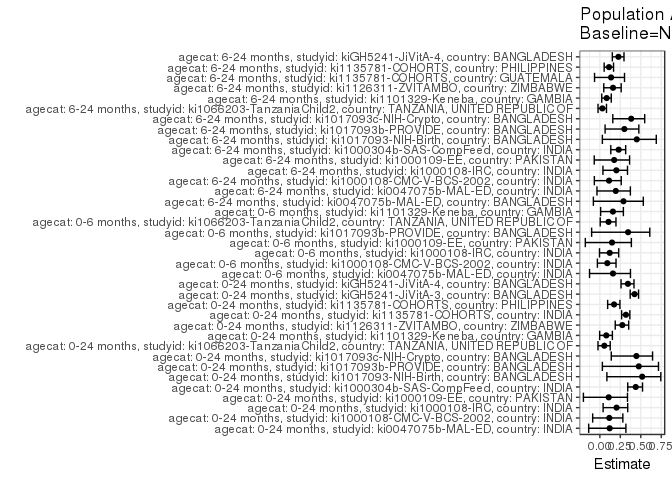

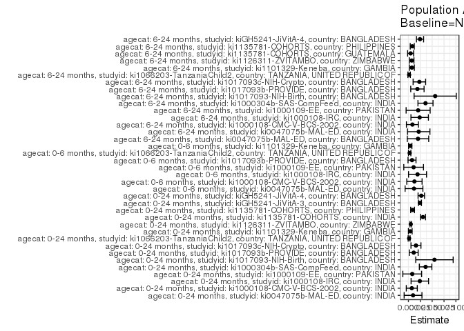

## Results Table

### Parameter: TSM

| agecat | studyid | country | intervention_level | baseline_level | estimate | ci_lower | ci_upper |
| --- | --- | --- | --- | --- | --- | --- | --- |
| 0-24 months | ki0047075b-MAL-ED | INDIA | Normal or high birthweight | NA | 0.0717949 | 0.0354843 | 0.1081055 |
| 0-24 months | ki0047075b-MAL-ED | INDIA | Low birth weight | NA | 0.1315789 | 0.0238708 | 0.2392871 |
| 0-24 months | ki1000108-CMC-V-BCS-2002 | INDIA | Normal or high birthweight | NA | 0.0545455 | 0.0300112 | 0.0790798 |
| 0-24 months | ki1000108-CMC-V-BCS-2002 | INDIA | Low birth weight | NA | 0.1162791 | 0.0203379 | 0.2122203 |
| 0-24 months | ki1000108-IRC | INDIA | Normal or high birthweight | NA | 0.0936425 | 0.0625061 | 0.1247789 |
| 0-24 months | ki1000108-IRC | INDIA | Low birth weight | NA | 0.2176595 | 0.1192487 | 0.3160702 |
| 0-24 months | ki1000109-EE | PAKISTAN | Normal or high birthweight | NA | 0.0662567 | 0.0349013 | 0.0976122 |
| 0-24 months | ki1000109-EE | PAKISTAN | Low birth weight | NA | 0.0702733 | 0.0265592 | 0.1139873 |
| 0-24 months | ki1000304b-SAS-CompFeed | INDIA | Normal or high birthweight | NA | 0.0464190 | 0.0312573 | 0.0615807 |
| 0-24 months | ki1000304b-SAS-CompFeed | INDIA | Low birth weight | NA | 0.2159084 | 0.1602111 | 0.2716057 |
| 0-24 months | ki1017093-NIH-Birth | BANGLADESH | Normal or high birthweight | NA | 0.0512821 | 0.0112025 | 0.0913616 |
| 0-24 months | ki1017093-NIH-Birth | BANGLADESH | Low birth weight | NA | 0.2096774 | 0.1080650 | 0.3112898 |
| 0-24 months | ki1017093b-PROVIDE | BANGLADESH | Normal or high birthweight | NA | 0.0122951 | 0.0025102 | 0.0220800 |
| 0-24 months | ki1017093b-PROVIDE | BANGLADESH | Low birth weight | NA | 0.0592105 | 0.0216604 | 0.0967607 |
| 0-24 months | ki1017093c-NIH-Crypto | BANGLADESH | Normal or high birthweight | NA | 0.0197184 | 0.0081970 | 0.0312399 |
| 0-24 months | ki1017093c-NIH-Crypto | BANGLADESH | Low birth weight | NA | 0.0871737 | 0.0447544 | 0.1295930 |
| 0-24 months | ki1066203-TanzaniaChild2 | TANZANIA, UNITED REPUBLIC OF | Normal or high birthweight | NA | 0.0251451 | 0.0183956 | 0.0318946 |
| 0-24 months | ki1066203-TanzaniaChild2 | TANZANIA, UNITED REPUBLIC OF | Low birth weight | NA | 0.0666667 | 0.0102001 | 0.1231333 |
| 0-24 months | ki1101329-Keneba | GAMBIA | Normal or high birthweight | NA | 0.0458000 | 0.0361055 | 0.0554945 |
| 0-24 months | ki1101329-Keneba | GAMBIA | Low birth weight | NA | 0.0823914 | 0.0453842 | 0.1193986 |
| 0-24 months | ki1126311-ZVITAMBO | ZIMBABWE | Normal or high birthweight | NA | 0.0130147 | 0.0105480 | 0.0154813 |
| 0-24 months | ki1126311-ZVITAMBO | ZIMBABWE | Low birth weight | NA | 0.0520844 | 0.0399929 | 0.0641760 |
| 0-24 months | ki1135781-COHORTS | INDIA | Normal or high birthweight | NA | 0.0656430 | 0.0582387 | 0.0730473 |
| 0-24 months | ki1135781-COHORTS | INDIA | Low birth weight | NA | 0.2197570 | 0.1951222 | 0.2443918 |
| 0-24 months | ki1135781-COHORTS | PHILIPPINES | Normal or high birthweight | NA | 0.0418020 | 0.0339739 | 0.0496301 |
| 0-24 months | ki1135781-COHORTS | PHILIPPINES | Low birth weight | NA | 0.1363942 | 0.0978456 | 0.1749428 |
| 0-24 months | kiGH5241-JiVitA-3 | BANGLADESH | Normal or high birthweight | NA | 0.0329656 | 0.0290208 | 0.0369104 |
| 0-24 months | kiGH5241-JiVitA-3 | BANGLADESH | Low birth weight | NA | 0.1025941 | 0.0942049 | 0.1109834 |
| 0-24 months | kiGH5241-JiVitA-4 | BANGLADESH | Normal or high birthweight | NA | 0.0520695 | 0.0431456 | 0.0609934 |
| 0-24 months | kiGH5241-JiVitA-4 | BANGLADESH | Low birth weight | NA | 0.1582109 | 0.1348022 | 0.1816196 |
| 0-6 months | ki0047075b-MAL-ED | INDIA | Normal or high birthweight | NA | 0.0615385 | 0.0277358 | 0.0953411 |
| 0-6 months | ki0047075b-MAL-ED | INDIA | Low birth weight | NA | 0.1351351 | 0.0247416 | 0.2455286 |
| 0-6 months | ki1000108-CMC-V-BCS-2002 | INDIA | Normal or high birthweight | NA | 0.1269959 | 0.0903061 | 0.1636856 |
| 0-6 months | ki1000108-CMC-V-BCS-2002 | INDIA | Low birth weight | NA | 0.2349657 | 0.1084637 | 0.3614677 |
| 0-6 months | ki1000108-IRC | INDIA | Normal or high birthweight | NA | 0.1403829 | 0.1030492 | 0.1777166 |
| 0-6 months | ki1000108-IRC | INDIA | Low birth weight | NA | 0.2532445 | 0.1490807 | 0.3574083 |
| 0-6 months | ki1000109-EE | PAKISTAN | Normal or high birthweight | NA | 0.0627899 | 0.0320182 | 0.0935617 |
| 0-6 months | ki1000109-EE | PAKISTAN | Low birth weight | NA | 0.0918281 | 0.0430763 | 0.1405799 |
| 0-6 months | ki1017093b-PROVIDE | BANGLADESH | Normal or high birthweight | NA | 0.0144033 | 0.0038022 | 0.0250044 |
| 0-6 months | ki1017093b-PROVIDE | BANGLADESH | Low birth weight | NA | 0.0463576 | 0.0127951 | 0.0799201 |
| 0-6 months | ki1066203-TanzaniaChild2 | TANZANIA, UNITED REPUBLIC OF | Normal or high birthweight | NA | 0.0223577 | 0.0158242 | 0.0288912 |
| 0-6 months | ki1066203-TanzaniaChild2 | TANZANIA, UNITED REPUBLIC OF | Low birth weight | NA | 0.0972222 | 0.0287741 | 0.1656703 |
| 0-6 months | ki1101329-Keneba | GAMBIA | Normal or high birthweight | NA | 0.0202617 | 0.0133186 | 0.0272049 |
| 0-6 months | ki1101329-Keneba | GAMBIA | Low birth weight | NA | 0.0689432 | 0.0314437 | 0.1064427 |
| 6-24 months | ki0047075b-MAL-ED | BANGLADESH | Normal or high birthweight | NA | 0.0497238 | 0.0179867 | 0.0814608 |
| 6-24 months | ki0047075b-MAL-ED | BANGLADESH | Low birth weight | NA | 0.1458333 | 0.0457694 | 0.2458973 |
| 6-24 months | ki0047075b-MAL-ED | INDIA | Normal or high birthweight | NA | 0.0899471 | 0.0490666 | 0.1308275 |
| 6-24 months | ki0047075b-MAL-ED | INDIA | Low birth weight | NA | 0.2285714 | 0.0891452 | 0.3679977 |
| 6-24 months | ki1000108-CMC-V-BCS-2002 | INDIA | Normal or high birthweight | NA | 0.0666667 | 0.0397174 | 0.0936159 |
| 6-24 months | ki1000108-CMC-V-BCS-2002 | INDIA | Low birth weight | NA | 0.1395349 | 0.0358287 | 0.2432411 |
| 6-24 months | ki1000108-IRC | INDIA | Normal or high birthweight | NA | 0.0939387 | 0.0627927 | 0.1250847 |
| 6-24 months | ki1000108-IRC | INDIA | Low birth weight | NA | 0.2319199 | 0.1321603 | 0.3316796 |
| 6-24 months | ki1000109-EE | PAKISTAN | Normal or high birthweight | NA | 0.0964092 | 0.0586844 | 0.1341339 |
| 6-24 months | ki1000109-EE | PAKISTAN | Low birth weight | NA | 0.1279612 | 0.0703945 | 0.1855280 |
| 6-24 months | ki1000304b-SAS-CompFeed | INDIA | Normal or high birthweight | NA | 0.1205382 | 0.1054250 | 0.1356515 |
| 6-24 months | ki1000304b-SAS-CompFeed | INDIA | Low birth weight | NA | 0.2936906 | 0.2346973 | 0.3526838 |
| 6-24 months | ki1017093-NIH-Birth | BANGLADESH | Normal or high birthweight | NA | 0.0686275 | 0.0194099 | 0.1178450 |
| 6-24 months | ki1017093-NIH-Birth | BANGLADESH | Low birth weight | NA | 0.2241379 | 0.1164801 | 0.3317957 |
| 6-24 months | ki1017093b-PROVIDE | BANGLADESH | Normal or high birthweight | NA | 0.0442842 | 0.0254115 | 0.0631569 |
| 6-24 months | ki1017093b-PROVIDE | BANGLADESH | Low birth weight | NA | 0.1303901 | 0.0760965 | 0.1846837 |
| 6-24 months | ki1017093c-NIH-Crypto | BANGLADESH | Normal or high birthweight | NA | 0.0371961 | 0.0210555 | 0.0533368 |
| 6-24 months | ki1017093c-NIH-Crypto | BANGLADESH | Low birth weight | NA | 0.1376582 | 0.0856827 | 0.1896336 |
| 6-24 months | ki1066203-TanzaniaChild2 | TANZANIA, UNITED REPUBLIC OF | Normal or high birthweight | NA | 0.0470948 | 0.0368234 | 0.0573662 |
| 6-24 months | ki1066203-TanzaniaChild2 | TANZANIA, UNITED REPUBLIC OF | Low birth weight | NA | 0.0943396 | 0.0156226 | 0.1730566 |
| 6-24 months | ki1101329-Keneba | GAMBIA | Normal or high birthweight | NA | 0.0803333 | 0.0673518 | 0.0933149 |
| 6-24 months | ki1101329-Keneba | GAMBIA | Low birth weight | NA | 0.1713405 | 0.1242083 | 0.2184727 |
| 6-24 months | ki1126311-ZVITAMBO | ZIMBABWE | Normal or high birthweight | NA | 0.0359272 | 0.0274894 | 0.0443650 |
| 6-24 months | ki1126311-ZVITAMBO | ZIMBABWE | Low birth weight | NA | 0.0702026 | 0.0443831 | 0.0960221 |
| 6-24 months | ki1135781-COHORTS | GUATEMALA | Normal or high birthweight | NA | 0.0288462 | 0.0157042 | 0.0419881 |
| 6-24 months | ki1135781-COHORTS | GUATEMALA | Low birth weight | NA | 0.0781250 | 0.0123282 | 0.1439218 |
| 6-24 months | ki1135781-COHORTS | PHILIPPINES | Normal or high birthweight | NA | 0.0642605 | 0.0543764 | 0.0741446 |
| 6-24 months | ki1135781-COHORTS | PHILIPPINES | Low birth weight | NA | 0.1697658 | 0.1266298 | 0.2129018 |
| 6-24 months | kiGH5241-JiVitA-4 | BANGLADESH | Normal or high birthweight | NA | 0.0833397 | 0.0702134 | 0.0964661 |
| 6-24 months | kiGH5241-JiVitA-4 | BANGLADESH | Low birth weight | NA | 0.1805008 | 0.1557827 | 0.2052189 |

### Parameter: E(Y)

| agecat | studyid | country | intervention_level | baseline_level | estimate | ci_lower | ci_upper |
| --- | --- | --- | --- | --- | --- | --- | --- |
| 0-24 months | ki0047075b-MAL-ED | INDIA | NA | NA | 0.0815451 | 0.0463297 | 0.1167604 |
| 0-24 months | ki1000108-CMC-V-BCS-2002 | INDIA | NA | NA | 0.0616622 | 0.0372186 | 0.0861058 |
| 0-24 months | ki1000108-IRC | INDIA | NA | NA | 0.1176471 | 0.0863457 | 0.1489484 |
| 0-24 months | ki1000109-EE | PAKISTAN | NA | NA | 0.0742706 | 0.0477670 | 0.1007741 |
| 0-24 months | ki1000304b-SAS-CompFeed | INDIA | NA | NA | 0.0825959 | 0.0584656 | 0.1067261 |
| 0-24 months | ki1017093-NIH-Birth | BANGLADESH | NA | NA | 0.1061453 | 0.0608949 | 0.1513956 |
| 0-24 months | ki1017093b-PROVIDE | BANGLADESH | NA | NA | 0.0234375 | 0.0117074 | 0.0351676 |
| 0-24 months | ki1017093c-NIH-Crypto | BANGLADESH | NA | NA | 0.0356164 | 0.0221630 | 0.0490699 |
| 0-24 months | ki1066203-TanzaniaChild2 | TANZANIA, UNITED REPUBLIC OF | NA | NA | 0.0265982 | 0.0197841 | 0.0334124 |
| 0-24 months | ki1101329-Keneba | GAMBIA | NA | NA | 0.0496957 | 0.0401018 | 0.0592897 |
| 0-24 months | ki1126311-ZVITAMBO | ZIMBABWE | NA | NA | 0.0179416 | 0.0152448 | 0.0206383 |
| 0-24 months | ki1135781-COHORTS | INDIA | NA | NA | 0.0962415 | 0.0882767 | 0.1042062 |
| 0-24 months | ki1135781-COHORTS | PHILIPPINES | NA | NA | 0.0505780 | 0.0424131 | 0.0587430 |
| 0-24 months | kiGH5241-JiVitA-3 | BANGLADESH | NA | NA | 0.0572012 | 0.0531104 | 0.0612920 |
| 0-24 months | kiGH5241-JiVitA-4 | BANGLADESH | NA | NA | 0.0791968 | 0.0700617 | 0.0883318 |
| 0-6 months | ki0047075b-MAL-ED | INDIA | NA | NA | 0.0732759 | 0.0396713 | 0.1068804 |
| 0-6 months | ki1000108-CMC-V-BCS-2002 | INDIA | NA | NA | 0.1396648 | 0.1037072 | 0.1756225 |
| 0-6 months | ki1000108-IRC | INDIA | NA | NA | 0.1596010 | 0.1237106 | 0.1954914 |
| 0-6 months | ki1000109-EE | PAKISTAN | NA | NA | 0.0737705 | 0.0469540 | 0.1005870 |
| 0-6 months | ki1017093b-PROVIDE | BANGLADESH | NA | NA | 0.0219780 | 0.0105837 | 0.0333723 |
| 0-6 months | ki1066203-TanzaniaChild2 | TANZANIA, UNITED REPUBLIC OF | NA | NA | 0.0250000 | 0.0182234 | 0.0317766 |
| 0-6 months | ki1101329-Keneba | GAMBIA | NA | NA | 0.0241102 | 0.0169050 | 0.0313155 |
| 6-24 months | ki0047075b-MAL-ED | BANGLADESH | NA | NA | 0.0698690 | 0.0367791 | 0.1029589 |
| 6-24 months | ki0047075b-MAL-ED | INDIA | NA | NA | 0.1116071 | 0.0702792 | 0.1529351 |
| 6-24 months | ki1000108-CMC-V-BCS-2002 | INDIA | NA | NA | 0.0750670 | 0.0482904 | 0.1018437 |
| 6-24 months | ki1000108-IRC | INDIA | NA | NA | 0.1176471 | 0.0863457 | 0.1489484 |
| 6-24 months | ki1000109-EE | PAKISTAN | NA | NA | 0.1168478 | 0.0839821 | 0.1497135 |
| 6-24 months | ki1000304b-SAS-CompFeed | INDIA | NA | NA | 0.1564854 | 0.1406022 | 0.1723685 |
| 6-24 months | ki1017093-NIH-Birth | BANGLADESH | NA | NA | 0.1250000 | 0.0735946 | 0.1764054 |
| 6-24 months | ki1017093b-PROVIDE | BANGLADESH | NA | NA | 0.0632280 | 0.0437545 | 0.0827015 |
| 6-24 months | ki1017093c-NIH-Crypto | BANGLADESH | NA | NA | 0.0602582 | 0.0425793 | 0.0779372 |
| 6-24 months | ki1066203-TanzaniaChild2 | TANZANIA, UNITED REPUBLIC OF | NA | NA | 0.0485782 | 0.0383194 | 0.0588370 |
| 6-24 months | ki1101329-Keneba | GAMBIA | NA | NA | 0.0875952 | 0.0746673 | 0.1005231 |
| 6-24 months | ki1126311-ZVITAMBO | ZIMBABWE | NA | NA | 0.0428121 | 0.0343875 | 0.0512367 |
| 6-24 months | ki1135781-COHORTS | GUATEMALA | NA | NA | 0.0334302 | 0.0199885 | 0.0468720 |
| 6-24 months | ki1135781-COHORTS | PHILIPPINES | NA | NA | 0.0723355 | 0.0623746 | 0.0822964 |
| 6-24 months | kiGH5241-JiVitA-4 | BANGLADESH | NA | NA | 0.1077830 | 0.0961106 | 0.1194554 |

### Parameter: RR

| agecat | studyid | country | intervention_level | baseline_level | estimate | ci_lower | ci_upper |
| --- | --- | --- | --- | --- | --- | --- | --- |
| 0-24 months | ki0047075b-MAL-ED | INDIA | Normal or high birthweight | Normal or high birthweight | 1.000000 | 1.0000000 | 1.000000 |
| 0-24 months | ki0047075b-MAL-ED | INDIA | Low birth weight | Normal or high birthweight | 1.832707 | 0.7001753 | 4.797105 |
| 0-24 months | ki1000108-CMC-V-BCS-2002 | INDIA | Normal or high birthweight | Normal or high birthweight | 1.000000 | 1.0000000 | 1.000000 |
| 0-24 months | ki1000108-CMC-V-BCS-2002 | INDIA | Low birth weight | Normal or high birthweight | 2.131783 | 0.8329568 | 5.455864 |
| 0-24 months | ki1000108-IRC | INDIA | Normal or high birthweight | Normal or high birthweight | 1.000000 | 1.0000000 | 1.000000 |
| 0-24 months | ki1000108-IRC | INDIA | Low birth weight | Normal or high birthweight | 2.324366 | 1.3266941 | 4.072287 |
| 0-24 months | ki1000109-EE | PAKISTAN | Normal or high birthweight | Normal or high birthweight | 1.000000 | 1.0000000 | 1.000000 |
| 0-24 months | ki1000109-EE | PAKISTAN | Low birth weight | Normal or high birthweight | 1.060621 | 0.4849233 | 2.319784 |
| 0-24 months | ki1000304b-SAS-CompFeed | INDIA | Normal or high birthweight | Normal or high birthweight | 1.000000 | 1.0000000 | 1.000000 |
| 0-24 months | ki1000304b-SAS-CompFeed | INDIA | Low birth weight | Normal or high birthweight | 4.651299 | 3.6453206 | 5.934890 |
| 0-24 months | ki1017093-NIH-Birth | BANGLADESH | Normal or high birthweight | Normal or high birthweight | 1.000000 | 1.0000000 | 1.000000 |
| 0-24 months | ki1017093-NIH-Birth | BANGLADESH | Low birth weight | Normal or high birthweight | 4.088710 | 1.6300733 | 10.255703 |
| 0-24 months | ki1017093b-PROVIDE | BANGLADESH | Normal or high birthweight | Normal or high birthweight | 1.000000 | 1.0000000 | 1.000000 |
| 0-24 months | ki1017093b-PROVIDE | BANGLADESH | Low birth weight | Normal or high birthweight | 4.815790 | 1.7406916 | 13.323341 |
| 0-24 months | ki1017093c-NIH-Crypto | BANGLADESH | Normal or high birthweight | Normal or high birthweight | 1.000000 | 1.0000000 | 1.000000 |
| 0-24 months | ki1017093c-NIH-Crypto | BANGLADESH | Low birth weight | Normal or high birthweight | 4.420926 | 2.0668068 | 9.456416 |
| 0-24 months | ki1066203-TanzaniaChild2 | TANZANIA, UNITED REPUBLIC OF | Normal or high birthweight | Normal or high birthweight | 1.000000 | 1.0000000 | 1.000000 |
| 0-24 months | ki1066203-TanzaniaChild2 | TANZANIA, UNITED REPUBLIC OF | Low birth weight | Normal or high birthweight | 2.651282 | 1.0903832 | 6.446630 |
| 0-24 months | ki1101329-Keneba | GAMBIA | Normal or high birthweight | Normal or high birthweight | 1.000000 | 1.0000000 | 1.000000 |
| 0-24 months | ki1101329-Keneba | GAMBIA | Low birth weight | Normal or high birthweight | 1.798939 | 1.0954685 | 2.954154 |
| 0-24 months | ki1126311-ZVITAMBO | ZIMBABWE | Normal or high birthweight | Normal or high birthweight | 1.000000 | 1.0000000 | 1.000000 |
| 0-24 months | ki1126311-ZVITAMBO | ZIMBABWE | Low birth weight | Normal or high birthweight | 4.001982 | 2.9662067 | 5.399443 |
| 0-24 months | ki1135781-COHORTS | INDIA | Normal or high birthweight | Normal or high birthweight | 1.000000 | 1.0000000 | 1.000000 |
| 0-24 months | ki1135781-COHORTS | INDIA | Low birth weight | Normal or high birthweight | 3.347760 | 2.8571312 | 3.922641 |
| 0-24 months | ki1135781-COHORTS | PHILIPPINES | Normal or high birthweight | Normal or high birthweight | 1.000000 | 1.0000000 | 1.000000 |
| 0-24 months | ki1135781-COHORTS | PHILIPPINES | Low birth weight | Normal or high birthweight | 3.262864 | 2.3265052 | 4.576084 |
| 0-24 months | kiGH5241-JiVitA-3 | BANGLADESH | Normal or high birthweight | Normal or high birthweight | 1.000000 | 1.0000000 | 1.000000 |
| 0-24 months | kiGH5241-JiVitA-3 | BANGLADESH | Low birth weight | Normal or high birthweight | 3.112157 | 2.7052465 | 3.580272 |
| 0-24 months | kiGH5241-JiVitA-4 | BANGLADESH | Normal or high birthweight | Normal or high birthweight | 1.000000 | 1.0000000 | 1.000000 |
| 0-24 months | kiGH5241-JiVitA-4 | BANGLADESH | Low birth weight | Normal or high birthweight | 3.038455 | 2.4232238 | 3.809887 |
| 0-6 months | ki0047075b-MAL-ED | INDIA | Normal or high birthweight | Normal or high birthweight | 1.000000 | 1.0000000 | 1.000000 |
| 0-6 months | ki0047075b-MAL-ED | INDIA | Low birth weight | Normal or high birthweight | 2.195946 | 0.8205345 | 5.876875 |
| 0-6 months | ki1000108-CMC-V-BCS-2002 | INDIA | Normal or high birthweight | Normal or high birthweight | 1.000000 | 1.0000000 | 1.000000 |
| 0-6 months | ki1000108-CMC-V-BCS-2002 | INDIA | Low birth weight | Normal or high birthweight | 1.850184 | 1.0049788 | 3.406222 |
| 0-6 months | ki1000108-IRC | INDIA | Normal or high birthweight | Normal or high birthweight | 1.000000 | 1.0000000 | 1.000000 |
| 0-6 months | ki1000108-IRC | INDIA | Low birth weight | Normal or high birthweight | 1.803956 | 1.1055868 | 2.943465 |
| 0-6 months | ki1000109-EE | PAKISTAN | Normal or high birthweight | Normal or high birthweight | 1.000000 | 1.0000000 | 1.000000 |
| 0-6 months | ki1000109-EE | PAKISTAN | Low birth weight | Normal or high birthweight | 1.462465 | 0.7100917 | 3.012010 |
| 0-6 months | ki1017093b-PROVIDE | BANGLADESH | Normal or high birthweight | Normal or high birthweight | 1.000000 | 1.0000000 | 1.000000 |
| 0-6 months | ki1017093b-PROVIDE | BANGLADESH | Low birth weight | Normal or high birthweight | 3.218543 | 1.1462663 | 9.037184 |
| 0-6 months | ki1066203-TanzaniaChild2 | TANZANIA, UNITED REPUBLIC OF | Normal or high birthweight | Normal or high birthweight | 1.000000 | 1.0000000 | 1.000000 |
| 0-6 months | ki1066203-TanzaniaChild2 | TANZANIA, UNITED REPUBLIC OF | Low birth weight | Normal or high birthweight | 4.348485 | 2.0290167 | 9.319451 |
| 0-6 months | ki1101329-Keneba | GAMBIA | Normal or high birthweight | Normal or high birthweight | 1.000000 | 1.0000000 | 1.000000 |
| 0-6 months | ki1101329-Keneba | GAMBIA | Low birth weight | Normal or high birthweight | 3.402634 | 1.7926424 | 6.458578 |
| 6-24 months | ki0047075b-MAL-ED | BANGLADESH | Normal or high birthweight | Normal or high birthweight | 1.000000 | 1.0000000 | 1.000000 |
| 6-24 months | ki0047075b-MAL-ED | BANGLADESH | Low birth weight | Normal or high birthweight | 2.932870 | 1.1489677 | 7.486484 |
| 6-24 months | ki0047075b-MAL-ED | INDIA | Normal or high birthweight | Normal or high birthweight | 1.000000 | 1.0000000 | 1.000000 |
| 6-24 months | ki0047075b-MAL-ED | INDIA | Low birth weight | Normal or high birthweight | 2.541177 | 1.1876006 | 5.437500 |
| 6-24 months | ki1000108-CMC-V-BCS-2002 | INDIA | Normal or high birthweight | Normal or high birthweight | 1.000000 | 1.0000000 | 1.000000 |
| 6-24 months | ki1000108-CMC-V-BCS-2002 | INDIA | Low birth weight | Normal or high birthweight | 2.093023 | 0.8981320 | 4.877620 |
| 6-24 months | ki1000108-IRC | INDIA | Normal or high birthweight | Normal or high birthweight | 1.000000 | 1.0000000 | 1.000000 |
| 6-24 months | ki1000108-IRC | INDIA | Low birth weight | Normal or high birthweight | 2.468843 | 1.4346200 | 4.248642 |
| 6-24 months | ki1000109-EE | PAKISTAN | Normal or high birthweight | Normal or high birthweight | 1.000000 | 1.0000000 | 1.000000 |
| 6-24 months | ki1000109-EE | PAKISTAN | Low birth weight | Normal or high birthweight | 1.327272 | 0.7317522 | 2.407443 |
| 6-24 months | ki1000304b-SAS-CompFeed | INDIA | Normal or high birthweight | Normal or high birthweight | 1.000000 | 1.0000000 | 1.000000 |
| 6-24 months | ki1000304b-SAS-CompFeed | INDIA | Low birth weight | Normal or high birthweight | 2.436493 | 1.8456619 | 3.216461 |
| 6-24 months | ki1017093-NIH-Birth | BANGLADESH | Normal or high birthweight | Normal or high birthweight | 1.000000 | 1.0000000 | 1.000000 |
| 6-24 months | ki1017093-NIH-Birth | BANGLADESH | Low birth weight | Normal or high birthweight | 3.266010 | 1.3776955 | 7.742509 |
| 6-24 months | ki1017093b-PROVIDE | BANGLADESH | Normal or high birthweight | Normal or high birthweight | 1.000000 | 1.0000000 | 1.000000 |
| 6-24 months | ki1017093b-PROVIDE | BANGLADESH | Low birth weight | Normal or high birthweight | 2.944393 | 1.6222100 | 5.344221 |
| 6-24 months | ki1017093c-NIH-Crypto | BANGLADESH | Normal or high birthweight | Normal or high birthweight | 1.000000 | 1.0000000 | 1.000000 |
| 6-24 months | ki1017093c-NIH-Crypto | BANGLADESH | Low birth weight | Normal or high birthweight | 3.700874 | 2.0834109 | 6.574060 |
| 6-24 months | ki1066203-TanzaniaChild2 | TANZANIA, UNITED REPUBLIC OF | Normal or high birthweight | Normal or high birthweight | 1.000000 | 1.0000000 | 1.000000 |
| 6-24 months | ki1066203-TanzaniaChild2 | TANZANIA, UNITED REPUBLIC OF | Low birth weight | Normal or high birthweight | 2.003185 | 0.8456118 | 4.745383 |
| 6-24 months | ki1101329-Keneba | GAMBIA | Normal or high birthweight | Normal or high birthweight | 1.000000 | 1.0000000 | 1.000000 |
| 6-24 months | ki1101329-Keneba | GAMBIA | Low birth weight | Normal or high birthweight | 2.132869 | 1.5509824 | 2.933064 |
| 6-24 months | ki1126311-ZVITAMBO | ZIMBABWE | Normal or high birthweight | Normal or high birthweight | 1.000000 | 1.0000000 | 1.000000 |
| 6-24 months | ki1126311-ZVITAMBO | ZIMBABWE | Low birth weight | Normal or high birthweight | 1.954024 | 1.2636530 | 3.021565 |
| 6-24 months | ki1135781-COHORTS | GUATEMALA | Normal or high birthweight | Normal or high birthweight | 1.000000 | 1.0000000 | 1.000000 |
| 6-24 months | ki1135781-COHORTS | GUATEMALA | Low birth weight | Normal or high birthweight | 2.708333 | 1.0395682 | 7.055881 |
| 6-24 months | ki1135781-COHORTS | PHILIPPINES | Normal or high birthweight | Normal or high birthweight | 1.000000 | 1.0000000 | 1.000000 |
| 6-24 months | ki1135781-COHORTS | PHILIPPINES | Low birth weight | Normal or high birthweight | 2.641838 | 1.9651043 | 3.551623 |
| 6-24 months | kiGH5241-JiVitA-4 | BANGLADESH | Normal or high birthweight | Normal or high birthweight | 1.000000 | 1.0000000 | 1.000000 |
| 6-24 months | kiGH5241-JiVitA-4 | BANGLADESH | Low birth weight | Normal or high birthweight | 2.165843 | 1.7583347 | 2.667794 |

### Parameter: PAR

| agecat | studyid | country | intervention_level | baseline_level | estimate | ci_lower | ci_upper |
| --- | --- | --- | --- | --- | --- | --- | --- |
| 0-24 months | ki0047075b-MAL-ED | INDIA | Normal or high birthweight | NA | 0.0097502 | -0.0090039 | 0.0285043 |
| 0-24 months | ki1000108-CMC-V-BCS-2002 | INDIA | Normal or high birthweight | NA | 0.0071167 | -0.0044739 | 0.0187074 |
| 0-24 months | ki1000108-IRC | INDIA | Normal or high birthweight | NA | 0.0240045 | 0.0055986 | 0.0424105 |
| 0-24 months | ki1000109-EE | PAKISTAN | Normal or high birthweight | NA | 0.0080138 | -0.0117882 | 0.0278158 |
| 0-24 months | ki1000304b-SAS-CompFeed | INDIA | Normal or high birthweight | NA | 0.0361769 | 0.0229785 | 0.0493754 |
| 0-24 months | ki1017093-NIH-Birth | BANGLADESH | Normal or high birthweight | NA | 0.0548632 | 0.0154422 | 0.0942842 |
| 0-24 months | ki1017093b-PROVIDE | BANGLADESH | Normal or high birthweight | NA | 0.0111424 | 0.0017973 | 0.0204875 |
| 0-24 months | ki1017093c-NIH-Crypto | BANGLADESH | Normal or high birthweight | NA | 0.0158980 | 0.0053911 | 0.0264049 |
| 0-24 months | ki1066203-TanzaniaChild2 | TANZANIA, UNITED REPUBLIC OF | Normal or high birthweight | NA | 0.0014532 | -0.0005632 | 0.0034695 |
| 0-24 months | ki1101329-Keneba | GAMBIA | Normal or high birthweight | NA | 0.0038957 | -0.0000288 | 0.0078203 |
| 0-24 months | ki1126311-ZVITAMBO | ZIMBABWE | Normal or high birthweight | NA | 0.0049269 | 0.0032903 | 0.0065635 |
| 0-24 months | ki1135781-COHORTS | INDIA | Normal or high birthweight | NA | 0.0305985 | 0.0252350 | 0.0359620 |
| 0-24 months | ki1135781-COHORTS | PHILIPPINES | Normal or high birthweight | NA | 0.0087760 | 0.0047639 | 0.0127882 |
| 0-24 months | kiGH5241-JiVitA-3 | BANGLADESH | Normal or high birthweight | NA | 0.0242356 | 0.0210005 | 0.0274707 |
| 0-24 months | kiGH5241-JiVitA-4 | BANGLADESH | Normal or high birthweight | NA | 0.0271272 | 0.0203191 | 0.0339353 |
| 0-6 months | ki0047075b-MAL-ED | INDIA | Normal or high birthweight | NA | 0.0117374 | -0.0070003 | 0.0304751 |
| 0-6 months | ki1000108-CMC-V-BCS-2002 | INDIA | Normal or high birthweight | NA | 0.0126689 | -0.0034334 | 0.0287713 |
| 0-6 months | ki1000108-IRC | INDIA | Normal or high birthweight | NA | 0.0192181 | 0.0002510 | 0.0381852 |
| 0-6 months | ki1000109-EE | PAKISTAN | Normal or high birthweight | NA | 0.0109806 | -0.0097514 | 0.0317125 |
| 0-6 months | ki1017093b-PROVIDE | BANGLADESH | Normal or high birthweight | NA | 0.0075747 | -0.0008352 | 0.0159847 |
| 0-6 months | ki1066203-TanzaniaChild2 | TANZANIA, UNITED REPUBLIC OF | Normal or high birthweight | NA | 0.0026423 | 0.0001425 | 0.0051420 |
| 0-6 months | ki1101329-Keneba | GAMBIA | Normal or high birthweight | NA | 0.0038485 | 0.0003322 | 0.0073649 |
| 6-24 months | ki0047075b-MAL-ED | BANGLADESH | Normal or high birthweight | NA | 0.0201452 | -0.0024368 | 0.0427273 |
| 6-24 months | ki0047075b-MAL-ED | INDIA | Normal or high birthweight | NA | 0.0216601 | -0.0019841 | 0.0453042 |
| 6-24 months | ki1000108-CMC-V-BCS-2002 | INDIA | Normal or high birthweight | NA | 0.0084004 | -0.0041764 | 0.0209772 |
| 6-24 months | ki1000108-IRC | INDIA | Normal or high birthweight | NA | 0.0237083 | 0.0053167 | 0.0421000 |
| 6-24 months | ki1000109-EE | PAKISTAN | Normal or high birthweight | NA | 0.0204387 | -0.0048736 | 0.0457509 |
| 6-24 months | ki1000304b-SAS-CompFeed | INDIA | Normal or high birthweight | NA | 0.0359471 | 0.0200936 | 0.0518007 |
| 6-24 months | ki1017093-NIH-Birth | BANGLADESH | Normal or high birthweight | NA | 0.0563725 | 0.0119163 | 0.1008288 |
| 6-24 months | ki1017093b-PROVIDE | BANGLADESH | Normal or high birthweight | NA | 0.0189437 | 0.0049054 | 0.0329821 |
| 6-24 months | ki1017093c-NIH-Crypto | BANGLADESH | Normal or high birthweight | NA | 0.0230621 | 0.0098685 | 0.0362557 |
| 6-24 months | ki1066203-TanzaniaChild2 | TANZANIA, UNITED REPUBLIC OF | Normal or high birthweight | NA | 0.0014834 | -0.0010399 | 0.0040067 |
| 6-24 months | ki1101329-Keneba | GAMBIA | Normal or high birthweight | NA | 0.0072619 | 0.0020680 | 0.0124558 |
| 6-24 months | ki1126311-ZVITAMBO | ZIMBABWE | Normal or high birthweight | NA | 0.0068849 | 0.0021614 | 0.0116084 |
| 6-24 months | ki1135781-COHORTS | GUATEMALA | Normal or high birthweight | NA | 0.0045841 | -0.0017486 | 0.0109167 |
| 6-24 months | ki1135781-COHORTS | PHILIPPINES | Normal or high birthweight | NA | 0.0080750 | 0.0038195 | 0.0123305 |
| 6-24 months | kiGH5241-JiVitA-4 | BANGLADESH | Normal or high birthweight | NA | 0.0244433 | 0.0169317 | 0.0319549 |

### Parameter: PAF

| agecat | studyid | country | intervention_level | baseline_level | estimate | ci_lower | ci_upper |
| --- | --- | --- | --- | --- | --- | --- | --- |
| 0-24 months | ki0047075b-MAL-ED | INDIA | Normal or high birthweight | NA | 0.1195682 | -0.1368486 | 0.3181500 |
| 0-24 months | ki1000108-CMC-V-BCS-2002 | INDIA | Normal or high birthweight | NA | 0.1154150 | -0.0878688 | 0.2807123 |
| 0-24 months | ki1000108-IRC | INDIA | Normal or high birthweight | NA | 0.2040387 | 0.0398693 | 0.3401373 |
| 0-24 months | ki1000109-EE | PAKISTAN | Normal or high birthweight | NA | 0.1079005 | -0.2010815 | 0.3373959 |
| 0-24 months | ki1000304b-SAS-CompFeed | INDIA | Normal or high birthweight | NA | 0.4379991 | 0.3403933 | 0.5211616 |
| 0-24 months | ki1017093-NIH-Birth | BANGLADESH | Normal or high birthweight | NA | 0.5168691 | 0.0857738 | 0.7446852 |
| 0-24 months | ki1017093b-PROVIDE | BANGLADESH | Normal or high birthweight | NA | 0.4754098 | 0.0305299 | 0.7161389 |
| 0-24 months | ki1017093c-NIH-Crypto | BANGLADESH | Normal or high birthweight | NA | 0.4463674 | 0.1394464 | 0.6438233 |
| 0-24 months | ki1066203-TanzaniaChild2 | TANZANIA, UNITED REPUBLIC OF | Normal or high birthweight | NA | 0.0546337 | -0.0229578 | 0.1263399 |
| 0-24 months | ki1101329-Keneba | GAMBIA | Normal or high birthweight | NA | 0.0783920 | -0.0026851 | 0.1529132 |
| 0-24 months | ki1126311-ZVITAMBO | ZIMBABWE | Normal or high birthweight | NA | 0.2746080 | 0.1877803 | 0.3521537 |
| 0-24 months | ki1135781-COHORTS | INDIA | Normal or high birthweight | NA | 0.3179345 | 0.2658953 | 0.3662847 |
| 0-24 months | ki1135781-COHORTS | PHILIPPINES | Normal or high birthweight | NA | 0.1735150 | 0.0950432 | 0.2451822 |
| 0-24 months | kiGH5241-JiVitA-3 | BANGLADESH | Normal or high birthweight | NA | 0.4236907 | 0.3702736 | 0.4725766 |
| 0-24 months | kiGH5241-JiVitA-4 | BANGLADESH | Normal or high birthweight | NA | 0.3425297 | 0.2587995 | 0.4168012 |
| 0-6 months | ki0047075b-MAL-ED | INDIA | Normal or high birthweight | NA | 0.1601810 | -0.1261692 | 0.3737212 |
| 0-6 months | ki1000108-CMC-V-BCS-2002 | INDIA | Normal or high birthweight | NA | 0.0907097 | -0.0301639 | 0.1974006 |
| 0-6 months | ki1000108-IRC | INDIA | Normal or high birthweight | NA | 0.1204136 | -0.0045602 | 0.2298398 |
| 0-6 months | ki1000109-EE | PAKISTAN | Normal or high birthweight | NA | 0.1488475 | -0.1776713 | 0.3848363 |
| 0-6 months | ki1017093b-PROVIDE | BANGLADESH | Normal or high birthweight | NA | 0.3446502 | -0.1005996 | 0.6097733 |
| 0-6 months | ki1066203-TanzaniaChild2 | TANZANIA, UNITED REPUBLIC OF | Normal or high birthweight | NA | 0.1056911 | 0.0043545 | 0.1967136 |
| 0-6 months | ki1101329-Keneba | GAMBIA | Normal or high birthweight | NA | 0.1596216 | 0.0092660 | 0.2871589 |
| 6-24 months | ki0047075b-MAL-ED | BANGLADESH | Normal or high birthweight | NA | 0.2883287 | -0.0792229 | 0.5307031 |
| 6-24 months | ki0047075b-MAL-ED | INDIA | Normal or high birthweight | NA | 0.1940741 | -0.0353623 | 0.3726673 |
| 6-24 months | ki1000108-CMC-V-BCS-2002 | INDIA | Normal or high birthweight | NA | 0.1119048 | -0.0675180 | 0.2611711 |
| 6-24 months | ki1000108-IRC | INDIA | Normal or high birthweight | NA | 0.2015210 | 0.0375250 | 0.3375737 |
| 6-24 months | ki1000109-EE | PAKISTAN | Normal or high birthweight | NA | 0.1749170 | -0.0686021 | 0.3629416 |
| 6-24 months | ki1000304b-SAS-CompFeed | INDIA | Normal or high birthweight | NA | 0.2297156 | 0.1334643 | 0.3152758 |
| 6-24 months | ki1017093-NIH-Birth | BANGLADESH | Normal or high birthweight | NA | 0.4509804 | 0.0304471 | 0.6891118 |
| 6-24 months | ki1017093b-PROVIDE | BANGLADESH | Normal or high birthweight | NA | 0.2996102 | 0.0637823 | 0.4760344 |
| 6-24 months | ki1017093c-NIH-Crypto | BANGLADESH | Normal or high birthweight | NA | 0.3827215 | 0.1580332 | 0.5474492 |
| 6-24 months | ki1066203-TanzaniaChild2 | TANZANIA, UNITED REPUBLIC OF | Normal or high birthweight | NA | 0.0305363 | -0.0224425 | 0.0807699 |
| 6-24 months | ki1101329-Keneba | GAMBIA | Normal or high birthweight | NA | 0.0829025 | 0.0227994 | 0.1393090 |
| 6-24 months | ki1126311-ZVITAMBO | ZIMBABWE | Normal or high birthweight | NA | 0.1608162 | 0.0478290 | 0.2603960 |
| 6-24 months | ki1135781-COHORTS | GUATEMALA | Normal or high birthweight | NA | 0.1371237 | -0.0651570 | 0.3009900 |
| 6-24 months | ki1135781-COHORTS | PHILIPPINES | Normal or high birthweight | NA | 0.1116329 | 0.0524905 | 0.1670838 |
| 6-24 months | kiGH5241-JiVitA-4 | BANGLADESH | Normal or high birthweight | NA | 0.2267822 | 0.1522544 | 0.2947581 |